# Regularization

## 6.1 LASSO

- Linear regression 모형

  $$y_i = \beta_0 + \beta_1 x_{1,i} + \cdots + \beta_p x_{p,i} + \epsilon_i,
  \quad \epsilon_i \sim N(0,\sigma^2) \quad (i = 1,2,...,n)$$
  또는
  $${\mathbf y} = X{\boldsymbol\beta} + {\boldsymbol\epsilon},\quad {\boldsymbol\epsilon}\sim N({\mathbf 0}_n, \sigma^2 I_n)$$
- ${\boldsymbol\beta}$의 최소제곱추정량

  $$\hat{\boldsymbol\beta} = (X^\top X)^{-1} X^\top {\mathbf y}$$
  - 제곱오차 $\| {\mathbf y} - X{\boldsymbol\beta} \|_2^2$ 를 최소로 하는 방법
  - 이론적으로 가장 우수한 방법임: BLUE (best linear unbiased estimator) 성질
- 고차원 자료 분석 시 모형이 매우 복잡해져서 결과적으로 분산이 매우 커지는 문제가 있음
  - $p$가 매우 큰 경우 최소제곱법으로 모형 적합 불가능
  - 즉, $X^\top X$의 역행렬이 존재하지 않음
- Ridge regression

  $$\hat{\boldsymbol{\beta}}_{\sf ridge} = (X^\top X + \lambda I)^{-1}X^\top{\mathbf y}$$
  - 학습 과정에서 추정치를 shrink시켜 약간의 bias를 감내하고 분산을 줄이는 아이디어
  - 최소제곱법에서 사용하는 제곱오차에 모형의 복잡도에 대해 벌점을 추가 부여한 손실함수를 최소로 하는 solution을 찾는 것과 동치임. 즉,

  $$\hat{\boldsymbol{\beta}}_{\sf ridge}
  =\arg\min_{\boldsymbol{\beta}}\left\{ \| {\mathbf y} - X{\boldsymbol{\beta}}\|_2^2 + \lambda \|{\boldsymbol{\beta}}\|_2^2 \right\}$$
- LASSO (least absolute shrinkage and selection operator)
  - 위의 ridge 회귀의 벌점 부분을 절대값 노옴(${\mathcal L}_1$)으로 대체
    $$\hat{\boldsymbol{\beta}}_{\sf lasso}
    =\arg\min_{\boldsymbol{\beta}}\left\{ \| {\mathbf y} - X{\boldsymbol{\beta}}\|_2^2 + \lambda \|{\boldsymbol{\beta}}\|_1 \right\}$$
  - 이 손실함수는 $\boldsymbol\beta$에 대해 convex
  - $\lambda$의 선택
    - 교차확인법(crossvalidation)
    - 베이지안 방법
  - 이 최적화 문제는 다음 문제와 동치
    $$\hat{\boldsymbol\beta}_{\sf lasso}
    =\arg\min_{\boldsymbol\beta}\| {\mathbf y} - X{\boldsymbol\beta}\|_2^2$$
    subject to
    $$\|{\boldsymbol{\beta}}\|_1 \le R$$
    for $R>0$

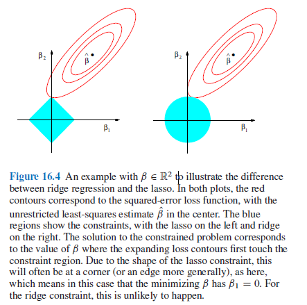

#### Example: 모의실험 데이터

```r
library(glmnet)
```

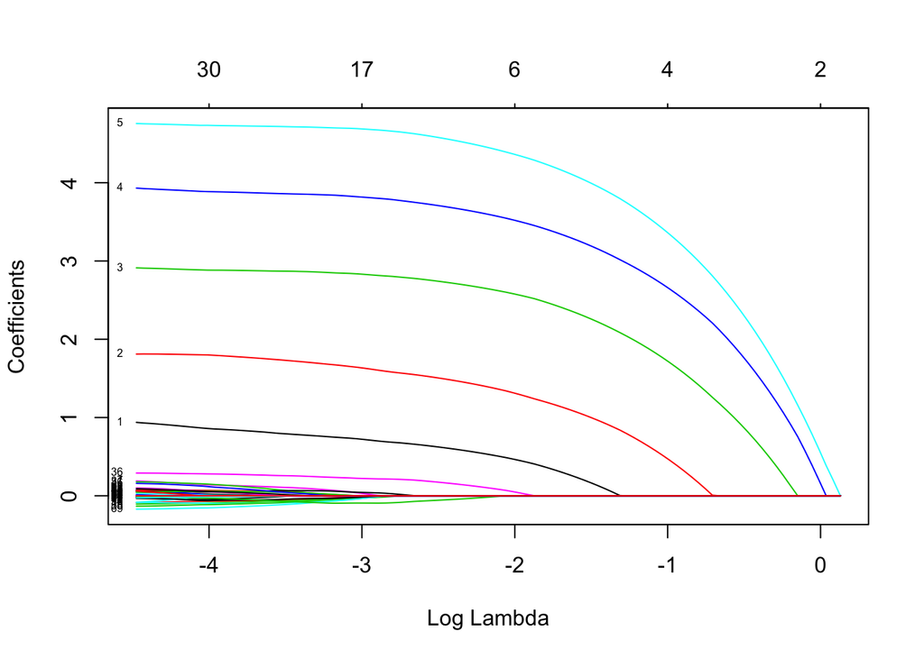

```r
set.seed(0)
n <- 50
p <- 100

sigma <- 0.25
beta <- c(1:5, rep(0, p - 5))

x <- cbind(matrix(runif(n*p), n, p))
y <- 10 + as.vector(x%*%beta) + sigma*rnorm(n)

fit <- glmnet(x, y)
plot(fit, xvar = "lambda", label = TRUE)
```

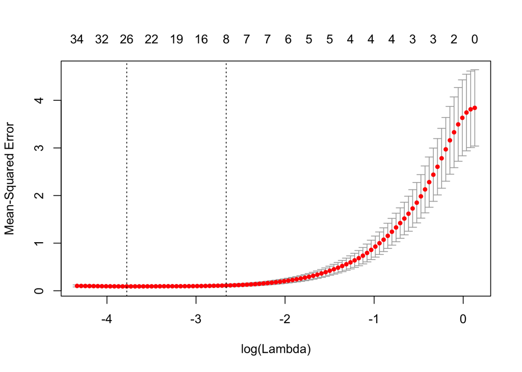

```r
cvfit <- cv.glmnet(x, y)
plot(cvfit)
```

```r
print(s <- cvfit$lambda.min)
```

```
## [1] 0.02287961
```

```r
print(beta.hat <- coef(cvfit, s = "lambda.min"))
```

```
## 101 x 1 sparse Matrix of class "dgCMatrix"
##                        1
## (Intercept) 10.370743731
## V1           0.833559111
## V2           1.771945018
## V3           2.879022777
## V4           3.875763697
## V5           4.726019401
## V6           .
## V7           0.126481344
## V8           .
## V9           0.011463797
## V10         -0.062694483
## V11          .
## V12          .
## V13          .
## V14          .
## V15         -0.079682170
## V16          .
## V17         -0.095697482
## V18         -0.002282135
## V19          .
## V20          .
## V21          .
## V22          .
## V23          .
## V24          .
## V25          .
## V26         -0.031592886
## V27          .
## V28          .
## V29          .
## V30          .
## V31          0.118216703
## V32          .
## V33          .
## V34          .
## V35          .
## V36          0.271640977
## V37          .
```

[output cut: 48 more lines]

```
## V86          0.087163948
## V87         -0.010053856
## V88          .
## V89          .
## V90          .
## V91          .
## V92          0.032086787
## V93          .
## V94          .
## V95          0.038901740
## V96          .
## V97          .
## V98          .
## V99          .
## V100         .
```

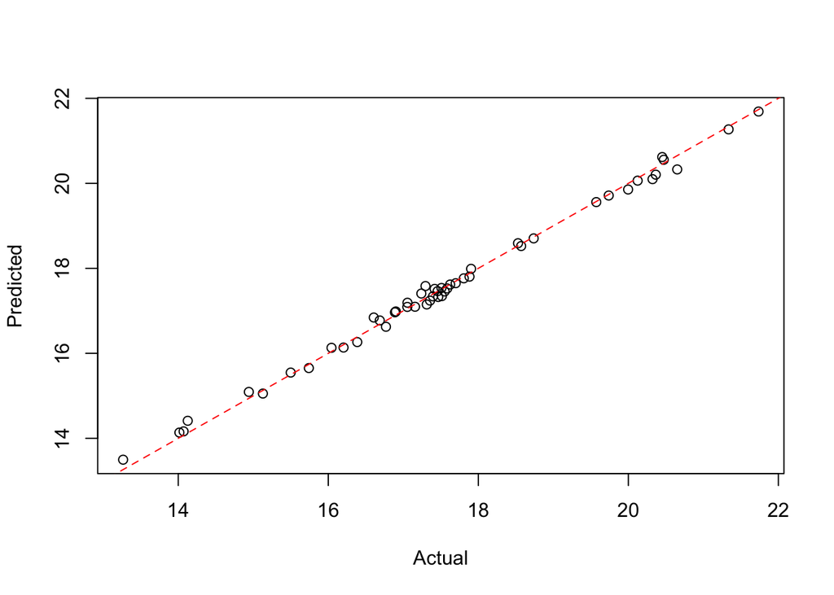

```r
pred.lasso <- predict(fit, newx = x, s = s)
plot(y, pred.lasso, xlab = "Actual", ylab = "Predicted")
abline(0, 1, col = 2, lty = 2)
```

#### Elastic-net

- 벌점 부분에 ${\mathcal L}_1$-norm과 ${\mathcal L}_2$-norm을 함께 사용
  $$\frac{1 - \alpha}{2} \|\boldsymbol\beta \|_2^2 + \alpha \|\boldsymbol\beta\|_1$$
- $\alpha = 0$이면 ridge regression, $\alpha = 1$이면 lasso regression에 해당

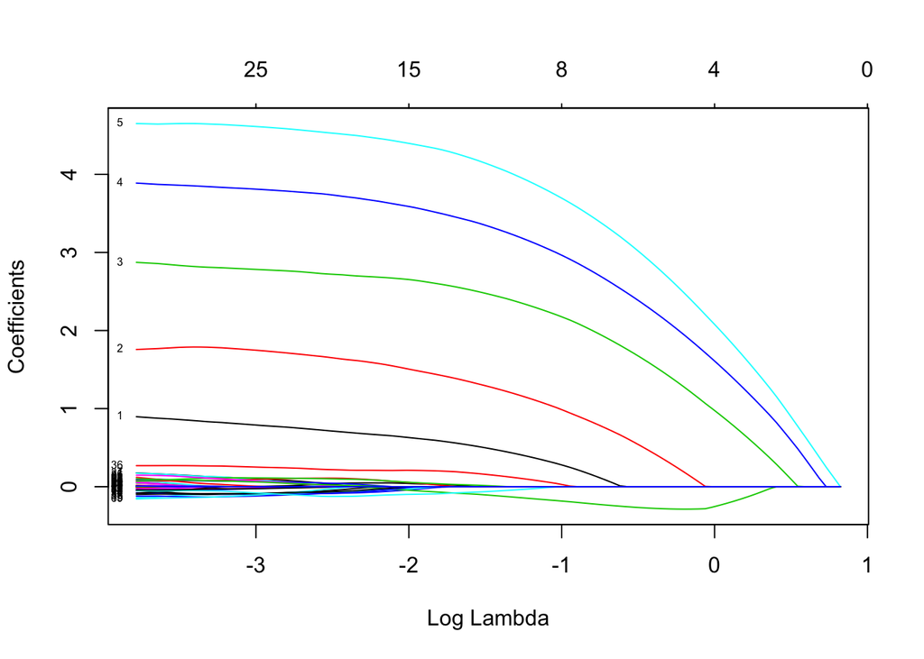

```r
fit <- glmnet(x, y, alpha = .5)
plot(fit, xvar = "lambda", label = TRUE)
```

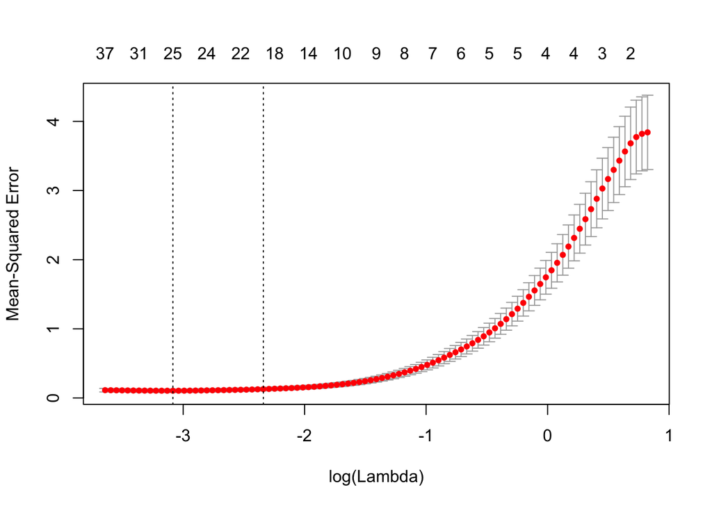

```r
cvfit <- cv.glmnet(x, y, alpha = .5)
plot(cvfit)
```

```r
print(cvfit$lambda.min)
```

```
## [1] 0.04575923
```

```r
print(s <- cvfit$lambda.min)
```

```
## [1] 0.04575923
```

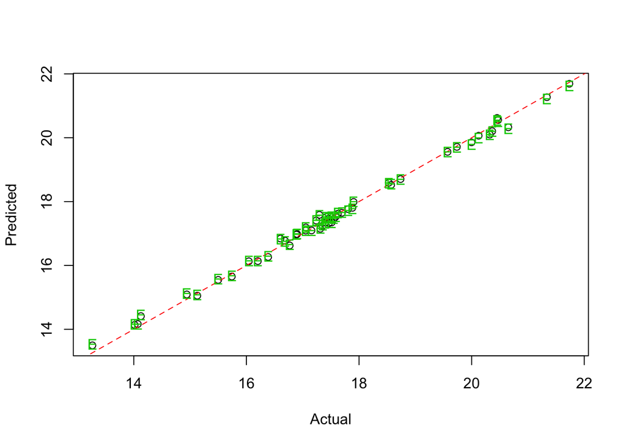

```r
plot(y, pred.lasso, xlab = "Actual", ylab = "Predicted")
abline(0, 1, col = 2, lty = 2)
points(y, predict(fit, newx = x, s = s), col = 3, pch = "E")
```

## 6.2 Non-normal $y$

- GLM 세팅에도 활용 가능
  - 반응변수 $y$가 연속형이 아니라 정규분포 가정이 불가능한 경우로 확장하는 모형 generalized linear model
    - Binary data: logistic regression
    - Count data: Poisson regression
  - 위 선형회귀모형과 달리 제곱오차가 아닌 우도함수값을 기준으로 모수 추정
  - Feature의 차원 $p$가 큰 경우 동일한 문제 발생

  ```r
  data(BinomialExample)

  fit <- glm(y ~ x, family = binomial("logit"))
  summary(fit)
  ```

  ```
  ##
  ## Call:
  ## glm(formula = y ~ x, family = binomial("logit"))
  ##
  ## Deviance Residuals:
  ##        Min          1Q      Median          3Q         Max
  ## -2.390e-05  -2.110e-08   2.110e-08   2.110e-08   2.256e-05
  ##
  ## Coefficients:
  ##               Estimate Std. Error z value Pr(>|z|)
  ## (Intercept)  7.815e+00  5.947e+04   0.000    1.000
  ## x1           1.536e+01  4.586e+04   0.000    1.000
  ## x2           4.219e+01  5.145e+04   0.001    0.999
  ## x3          -1.483e+01  5.276e+04   0.000    1.000
  ## x4          -2.831e+01  3.652e+04  -0.001    0.999
  ## x5          -4.968e+00  5.440e+04   0.000    1.000
  ## x6          -4.099e+01  5.211e+04  -0.001    0.999
  ## x7           1.176e+01  6.024e+04   0.000    1.000
  ## x8          -1.903e+01  6.449e+04   0.000    1.000
  ## x9           2.635e+01  6.535e+04   0.000    1.000
  ## x10         -5.263e+01  3.916e+04  -0.001    0.999
  ## x11         -1.079e+01  2.989e+04   0.000    1.000
  ## x12         -1.260e+01  9.747e+04   0.000    1.000
  ## x13         -1.591e+01  7.995e+04   0.000    1.000
  ## x14          1.435e+01  7.826e+04   0.000    1.000
  ## x15          1.976e+00  5.687e+04   0.000    1.000
  ## x16          2.148e+01  6.137e+04   0.000    1.000
  ## x17         -3.592e+00  9.982e+04   0.000    1.000
  ## x18         -2.154e+01  4.172e+04  -0.001    1.000
  ## x19         -1.736e+01  4.095e+04   0.000    1.000
  ## x20         -1.016e+01  3.951e+04   0.000    1.000
  ## x21          3.405e-01  4.589e+04   0.000    1.000
  ## x22          1.099e+01  4.842e+04   0.000    1.000
  ## x23          2.505e+01  5.916e+04   0.000    1.000
  ## x24         -1.740e+01  1.136e+05   0.000    1.000
  ## x25          1.387e+01  6.853e+04   0.000    1.000
  ## x26         -6.979e+00  3.488e+04   0.000    1.000
  ## x27         -1.540e+01  2.991e+04  -0.001    1.000
  ## x28          2.715e+01  4.363e+04   0.001    1.000
  ## x29         -9.921e+00  4.996e+04   0.000    1.000
  ## x30          6.700e+00  5.586e+04   0.000    1.000
  ##
  ## (Dispersion parameter for binomial family taken to be 1)
  ##
  ##     Null deviance: 1.3719e+02  on 99  degrees of freedom
  ## Residual deviance: 6.9742e-09  on 69  degrees of freedom
  ## AIC: 62
  ##
  ## Number of Fisher Scoring iterations: 25
  ```

  - Negative log-likelihood + lasso penalty 를 최소로 하는 회귀계수

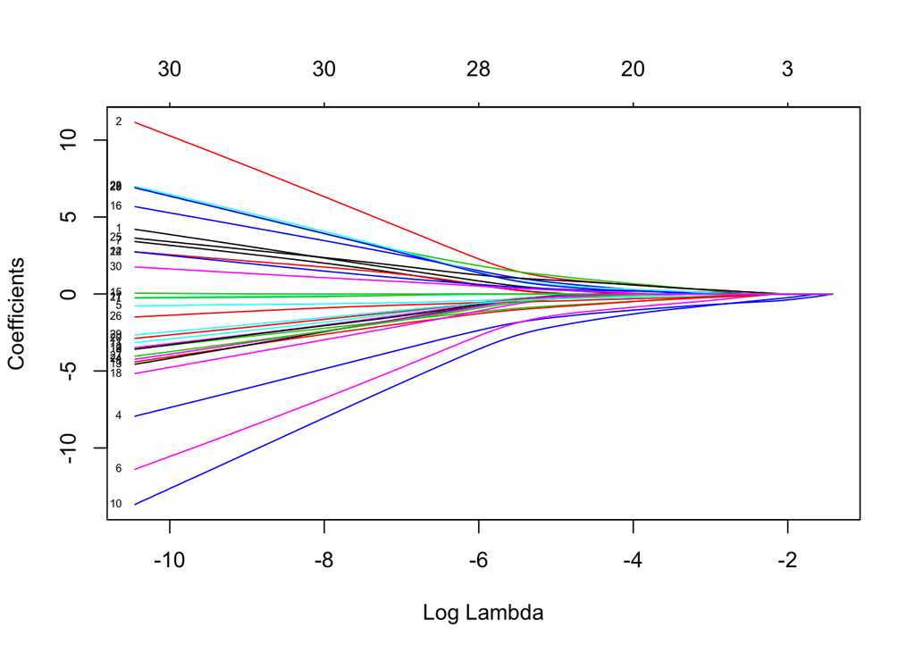

  ```r
  fit <- glmnet(x, y, family = "binomial")
  plot(fit, xvar = "lambda", label = TRUE)
  ```

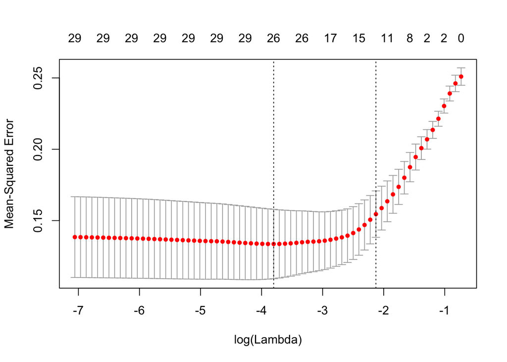

  ```r
  cvfit <- cv.glmnet(x, y, alpha = .5)
  plot(cvfit)
  ```

  ```r
  print(cvfit$lambda.min)
  ```

  ```
  ## [1] 0.02232384
  ```

  ```r
  print(s <- cvfit$lambda.min)
  ```

  ```
  ## [1] 0.02232384
  ```

  ```r
  pred <- predict(fit, newx = x, type = "class", s = s)
  table(y, pred)
  ```

  ```
  ##    pred
  ## y    0  1
  ##   0 43  1
  ##   1  1 55
  ```